# Risk Model Decision Analysis

A tutorial for R package `rmda`

Marshall Brown

March 20, 2018

The package `rmda` (risk model decision analysis) provides tools to evaluate the value of using a risk prediction instrument to decide treatment or intervention (versus no treatment or intervention). Given one or more risk prediction instruments (risk models) that estimate the probability of a binary outcome, `rmda` provides functions to estimate and display decision curves and other figures that help assess the population impact of using a risk model for clinical decision making. Here, “population” refers to the relevant patient population.

Decision curves display estimates of the (standardized) net benefit over a range of probability thresholds used to categorize observations as ‘high risk.’ The curves help evaluate a treatment policy that recommends treatment for patients who are estimated to be ‘high risk’ by comparing the population impact of a risk-based policy to “treat all” and “treat none” intervention policies. Curves can be estimated using data from a prospective cohort. In addition, `rmda` can estimate decision curves using data from a case-control study if an estimate of the population outcome prevalence is available. Version 1.5 and higher of the package provides an alternative framing of the decision problem for situations where treatment is the standard-of-care and a risk model might be used to recommend that low-risk patients (i.e., patients below some risk threshold) opt-out of treatment.

Confidence intervals calculated using the bootstrap can be computed and displayed. A wrapper function to calculate cross-validated curves using k-fold cross-validation is also provided.

Key functions are:

- `decision_curve`: Estimate (standardized) net benefit curves with bootstrap confidence intervals.
- `plot_decision_curve`: Plot a decision curve or multiple curves.
- `plot_clinical_impact` and `plot_roc_components`: Alternative plots for the output of `decision_curve` showing measures of clinical impact or the components of the ROC curve (true/false positive rates) across a range of risk thresholds. See help files or tutorial for more info.
- `cv_decision_curve`: Calculate k-fold cross-validated estimates of a decision curve and its components.

## Install the package

The easiest way to get the package is directly from CRAN:

```r
install.packages("rmda")
```

You may also download the current version of the package here:

https://github.com/mdbrown/rmda/releases

navigate to the source package and use

```r
install.packages("../rmda_1.5.tar.gz", repos = NULL, type = "source")
```

or install the package directly from github using devtools.

```r
## install.packages("devtools")
library(devtools)
install_github("mdbrown/rmda")
```

## Getting started

Load the package and the provided simulated data set.

```r
library(rmda)

#load simulated data
data(dcaData)

head(dcaData)
```

```
## # A tibble: 6 x 6
##     Age Female Smokes   Marker1     Marker2 Cancer
##   <int>  <dbl>  <lgl>     <dbl>       <dbl>  <int>
## 1    33      1  FALSE 0.2453110  1.02108482      0
## 2    29      1  FALSE 0.9429660 -0.25576212      0
## 3    28      1  FALSE 0.7735939  0.33184401      0
## 4    27      0  FALSE 0.4063595 -0.00568574      0
## 5    23      1  FALSE 0.5075153  0.20753273      0
## 6    35      1  FALSE 0.1856706  1.41251020      0
```

First we use the function `decision_curve` to create a decision curve object for a logistic model to predict cancer status using age, gender and smoking status. We then plot it using `plot_decision_curve`.

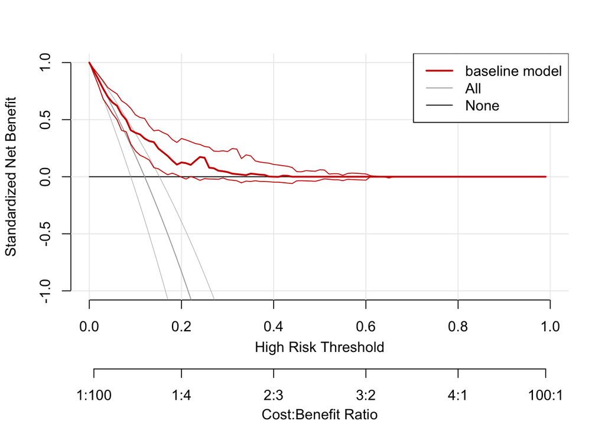

```r
set.seed(123)
#first use rmda with the default settings (set bootstraps = 50 here to reduce computation time).
baseline.model <- decision_curve(Cancer~Age + Female + Smokes, #fitting a logistic model
                                data = dcaData,
                                study.design = "cohort",
                                policy = "opt-in",  #default
                                bootstraps = 50)

#plot the curve
plot_decision_curve(baseline.model,  curve.names = "baseline model")
```

Next, we create a decision curve with two markers added to the original baseline model. We then pass a list with both decision curves to `plot_decision_curve` to plot both curves.

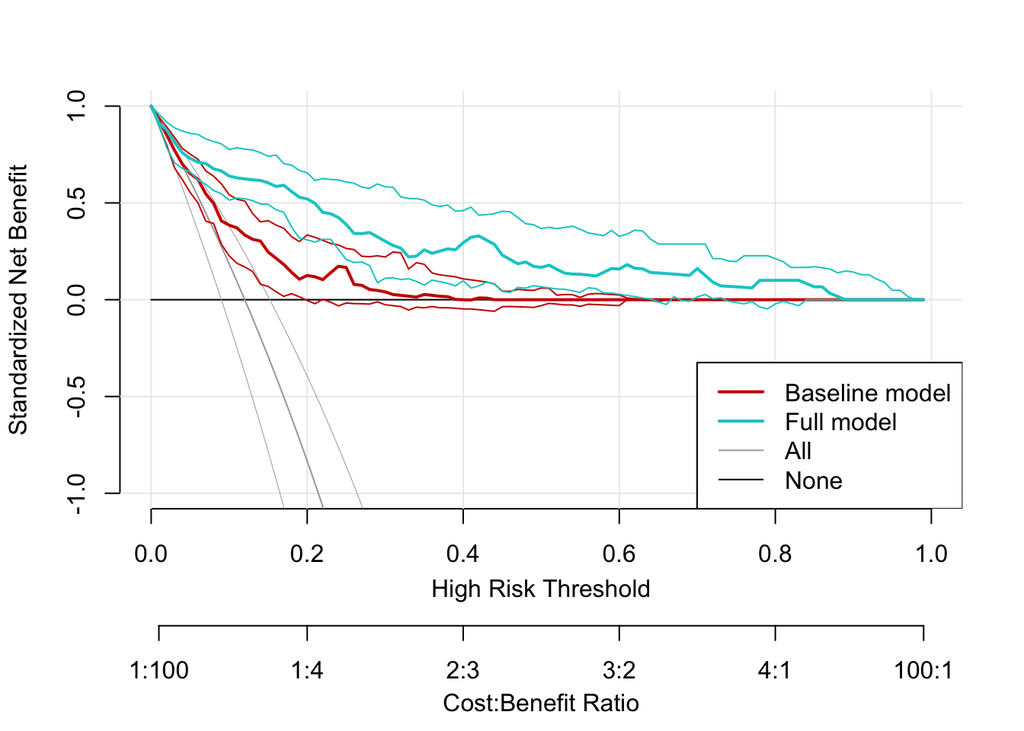

```r
set.seed(123)
full.model <- decision_curve(Cancer~Age + Female + Smokes + Marker1 + Marker2,
              data = dcaData,
              bootstraps = 50)

#since we want to plot more than one curve, we pass a list of 'decision_curve' objects to the plot
plot_decision_curve( list(baseline.model, full.model),
                   curve.names = c("Baseline model", "Full model"), xlim = c(0, 1), legend.position = "bottomright")
```

```r
#see all available options using
?decision_curve
?plot_decision_curve
```

## Alternative plotting functions

We include two other functions `plot_roc_components` and `plot_clinical_impact`.

`plot_roc_components` plots the components of the ROC curve-true positive rate and false positive rates-over a range of high risk thresholds.

If we were to use the specified model to classify 1,000 hypothetical subjects, `plot_clinical_impact` plots the number classified as high risk and the number with the outcome classified as high risk for a given high risk threshold.

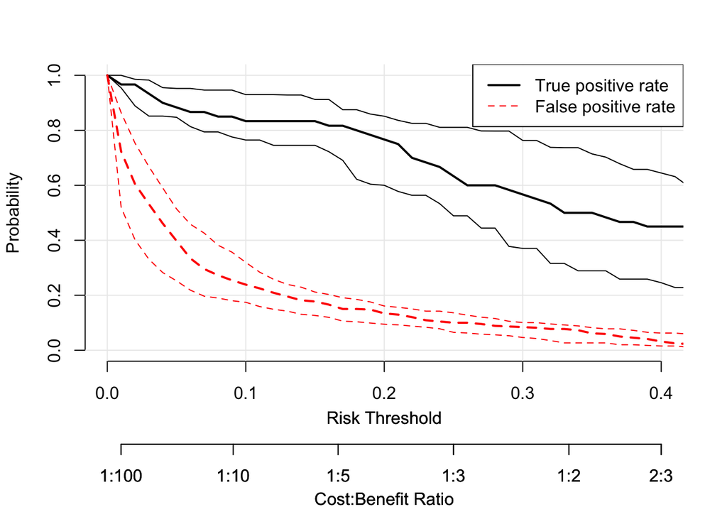

```r
#plot the components of the roc curve--true positive rate and false positive rate
plot_roc_components(full.model,  xlim = c(0, 0.4),
                    col = c("black", "red"))
```

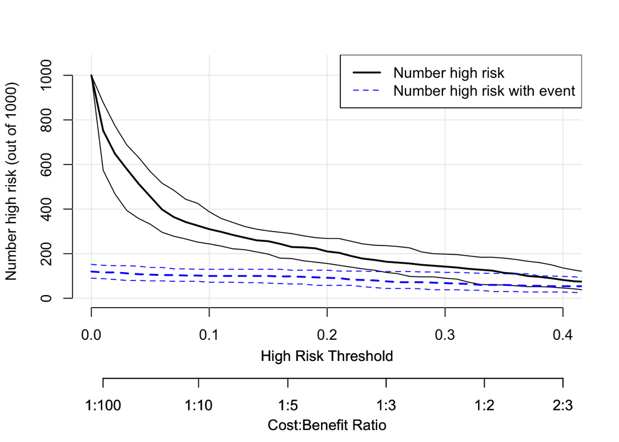

```r
#plot the clinical impact
plot_clinical_impact(full.model, xlim = c(0, .4),
                     col = c("black", "blue"))
```

## The net benefit of an ‘opt-out’ vs. ‘opt-in’ policy

For many clinical contexts, a risk model is used in one of two ways. In the first setting, the standard-of-care for a population is to assign a particular ‘treatment’ to no one. Clinicians then use a risk model to categorize patients as ‘high-risk’, with the recommendation to treat high-risk patients with some intervention. We refer to this use of a risk model as an ‘opt-in’ policy. The relative costs and benefits of such a policy are specified as the ‘cost’ of treating an individual without the event (a control) compared to the ‘benefit’ of treating an observation with the event (a case).

The standardized net benefit for an ‘opt-in’ policy is defined in terms of the true and false positive rates, the outcome prevalence $\rho$, and the risk threshold $r$.

$$sNB^{(opt-in)}(r) = TPR(r) - \Big(\frac{1-\rho}{\rho}\Big)\Big(\frac{r}{1-r}\Big)FPR(r)$$
Alternatively, there are contexts where the standard-of-care is to recommend a treatment to an entire patient population. The potential use of a risk model in this setting is to identify patients who are ‘low-risk’ and recommend that those patients ‘opt-out’ of treatment.

$$sNB^{(opt-out)}(r) =TNR(r) - \Big(\frac{\rho}{ 1-\rho} \Big)\Big(\frac{1-r}{r}\Big)FNR(r)$$

So far in this tutorial we have calculated the net benefit curves using the default `policy = 'opt-in'` setting. To calculate the net benefit for an ‘opt-out’ policy, we set `policy = 'opt-out'` when using the `decision_curve` function.

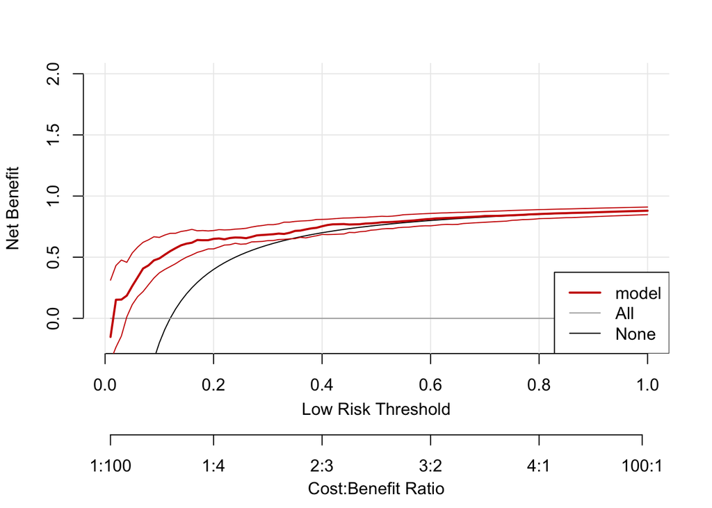

```r
set.seed(123)
opt.out.dc <- decision_curve(Cancer~Age + Female + Smokes + Marker1 + Marker2,
              data = dcaData,
              bootstraps = 50,
              policy = 'opt-out') #set policy = 'opt-out' (default is 'opt-in')


plot_decision_curve( opt.out.dc,  xlim = c(0, 1), ylim = c(-.2,2),
                     standardize = FALSE,
                     curve.names = "model", legend = 'bottomright')
```

The clinical impact plots are also influenced by the `policy` argument. When we set policy = ‘opt-out’ the clinical impact plot displays the number considered low risk at each threshold instead of the number high risk.

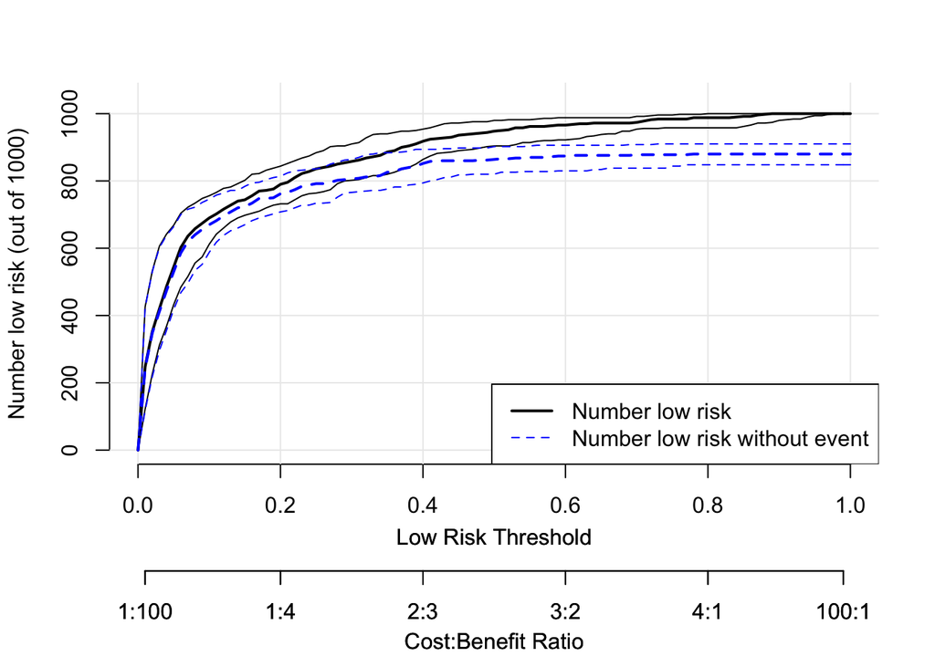

```r
plot_clinical_impact( opt.out.dc, col = c("black", "blue"), legend = 'bottomright')
```

## Tweaking the defaults

We show several examples of how one might change the default settings.

- Fine tune the thresholds, move the legend, and change linewidth and colors. Here we are calculating many more points on the curve (see the ‘thresholds’ setting).

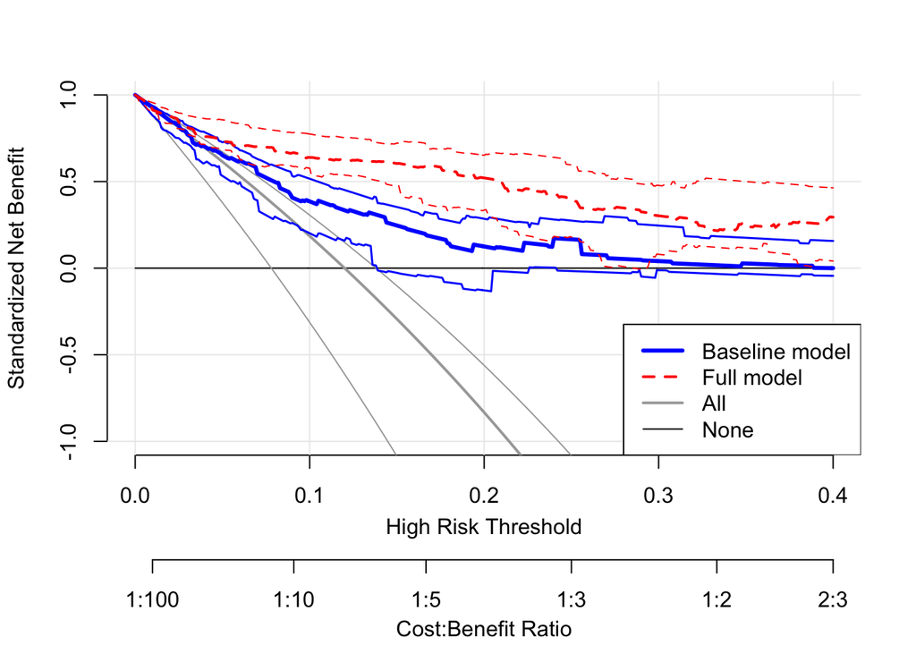

```r
baseline.model <- decision_curve(Cancer~Age + Female + Smokes,
                                data = dcaData,
                                 thresholds = seq(0, .4, by = .001),# calculate thresholds from 0-0.4 at every 0.001 increment.
                                bootstraps = 25)

full.model <- decision_curve(Cancer~Age + Female + Smokes + Marker1 + Marker2,
                            data = dcaData,
                            thresholds = seq(0, .4, by = .001),# calculate thresholds from 0-0.4 at every 0.001 increment.
                            bootstraps = 25)


plot_decision_curve( list(baseline.model, full.model),
                   curve.names = c("Baseline model", "Full model"),
                   col = c("blue", "red"),
                   lty = c(1,2),
                   lwd = c(3,2, 2, 1),  # the first two correspond to the decision curves, then 'all' and then 'none'
                   legend.position = "bottomright") #adjust the legend position
```

- No confidence intervals, cost:benefit ratio axis, or legend

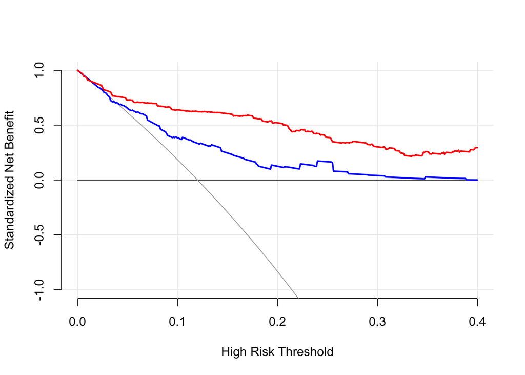

```r
plot_decision_curve( list(baseline.model, full.model),
                   curve.names = c("Baseline model", "Full model"),
                   col = c("blue", "red"),
                   confidence.intervals = FALSE,  #remove confidence intervals
                   cost.benefit.axis = FALSE, #remove cost benefit axis
                   legend.position = "none") #remove the legend
```

- Print specific cost:benefit ratios.

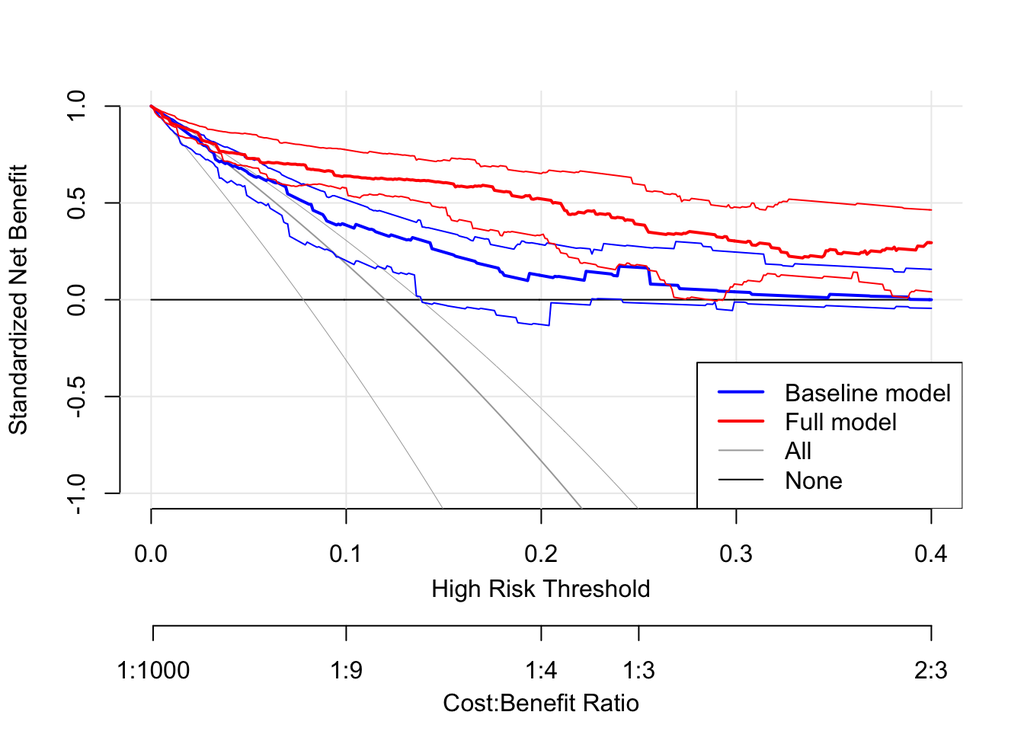

```r
plot_decision_curve( list(baseline.model, full.model),
                   curve.names = c("Baseline model", "Full model"),
                   col = c("blue", "red"),
                  cost.benefits = c("1:1000", "1:4", "1:9", "2:3", "1:3"),  #set specific cost benefits
                   legend.position = "bottomright")
```

- Plot net benefit instead of standardize net benefit, change confidence interval level.

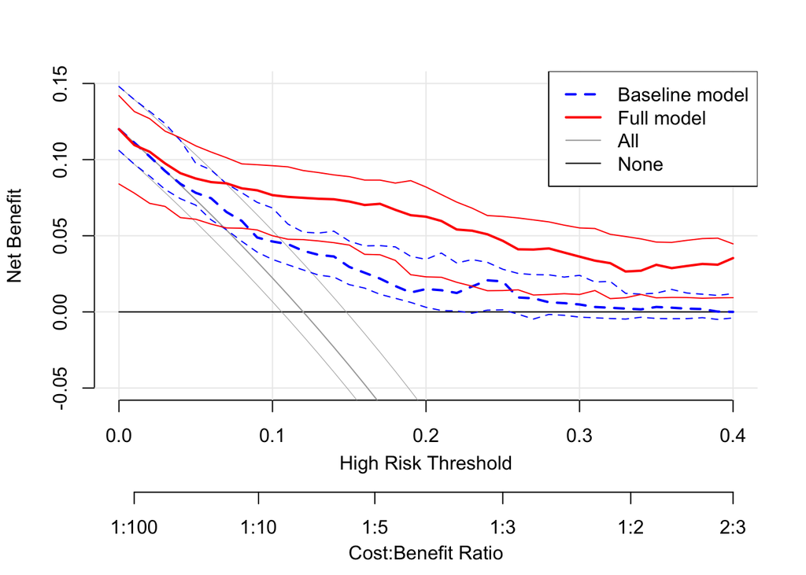

```r
baseline.model <- decision_curve(Cancer~Age + Female + Smokes,
                                data = dcaData,
                                thresholds = seq(0, .4, by = .01),
                                confidence.intervals = 0.9, #calculate 90% confidence intervals
                                bootstraps = 25)

full.model <- decision_curve(Cancer~Age + Female + Smokes + Marker1 + Marker2,
                            data = dcaData,
                            thresholds = seq(0, .40, by = .01),
                            confidence.intervals = 0.9, #calculate 90% confidence intervals
                            bootstraps = 25)

plot_decision_curve( list(baseline.model, full.model),
                   curve.names = c("Baseline model", "Full model"),
                   col = c("blue", "red"),
                   ylim = c(-0.05, 0.15), #set ylim
                   lty = c(2,1),
                   standardize = FALSE, #plot Net benefit instead of standardized net benefit
                   legend.position = "topright")
```

## Providing fitted risks from a previously specified model

If a risk model has already been specified, and so no model fitting is needed, the user can specify `fitted.risks=TRUE` and provide them in the formula. No model fitting will be done and bootstrap confidence intervals will be conditional on the fitted model.

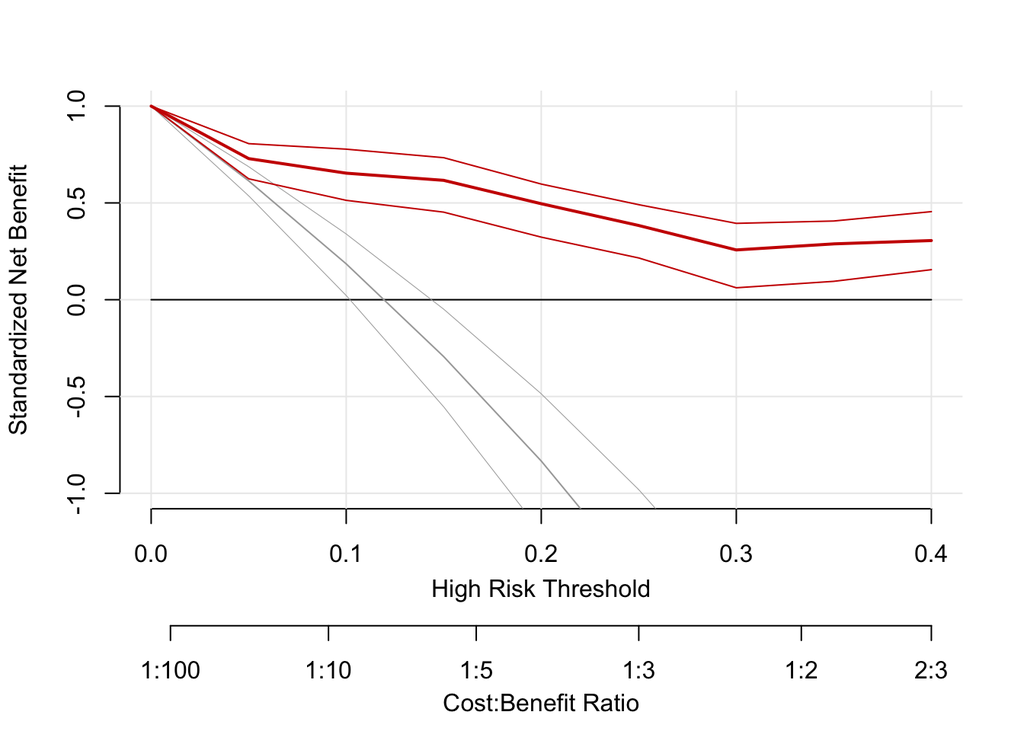

```r
#helper function

expit <- function(xx) exp(xx)/ (1+exp(xx))
# Assume we have access to previously published models
# (or models built using a training set)
# that we can use to predict the risk of cancer.

# Basic model using demographic variables: Age, Female, Smokes.
dcaData$BasicModel <- with(dcaData, expit(-7.3 + 0.18*Age - 0.08*Female + 0.80*Smokes ) )

# Model using demographic + markers : Age, Female, Smokes, Marker1 and Marker2.
dcaData$FullModel <- with(dcaData, expit(-10.5 + 0.22*Age  - 0.01*Female + 0.91*Smokes + 2.03*Marker1 - 1.56*Marker2))


full.model <- decision_curve(Cancer~FullModel,
                            data = dcaData,
                            fitted.risk = TRUE,
                            thresholds = seq(0, .4, by = .05),
                            bootstraps = 25)


plot_decision_curve(full.model, legend.position = "none")
```

## Printing estimates

`decision_curve` also outputs all calculations and point estimates when assigned to an object.

```r
full.model <- decision_curve(Cancer~Age + Female + Smokes + Marker1 + Marker2,
                            data = dcaData,
                            thresholds = seq(.01, .99, by = .05),
                            bootstraps = 25, policy = "opt-out")
```

The best way to look at point estimates (w/ci’s) is to use `summary`.

```r
summary(full.model, measure = "NB") #outputs standardized net benefit by default
```

```
##
## Net Benefit (95% Confidence Intervals):
## --------------------------------------------------------------------------------------------
##    risk      cost:benefit     percent       All     Cancer ~ Age + Female + Smokes    None
##  threshold      ratio         low risk                   + Marker1 + Marker2
## ----------- -------------- -------------- -------- -------------------------------- --------
##    0.01          1:99           24.8         0                  -0.152                -11
##                             (13.4, 44.4)   (0, 0)           (-0.532, 0.29)
##
##    0.06          3:47           60.2         0                  0.335                  -1
##                             (49.4, 72.2)   (0, 0)           (0.194, 0.555)
##
##    0.11         11:89           70.2         0                   0.52                -0.091
##                             (63.2, 80.4)   (0, 0)           (0.341, 0.695)
##
##    0.16          4:21           75.6         0                  0.618                 0.25
##                             (70.4, 84.2)   (0, 0)           (0.504, 0.717)
##
##    0.21         21:79           79.6         0                  0.653                0.429
##                             (75.2, 87.6)   (0, 0)           (0.558, 0.762)
##
##    0.26         13:37            84          0                  0.655                0.538
##                             (79.2, 90.8)   (0, 0)           (0.615, 0.773)
##
##    0.31         31:69           86.2         0                  0.688                0.613
##                             (82.6, 93.2)   (0, 0)           (0.639, 0.792)
##
##    0.36          9:16            89          0                  0.718                0.667
##                             (84.8, 94.6)   (0, 0)           (0.665, 0.822)
##
##    0.41         41:59           92.4         0                  0.763                0.707
##                             (86.4, 96.6)   (0, 0)           (0.703, 0.838)
##
##    0.46         23:27           93.8         0                  0.768                0.739
##                             (89.8, 97.8)   (0, 0)           (0.717, 0.845)
##
##    0.51         51:49            95          0                  0.785                0.765
##                              (91.2, 98)    (0, 0)           (0.742, 0.848)
##
##    0.56         14:11           96.2         0                  0.798                0.786
```

[output cut: 11 more lines]

```
##    0.76          19:6           98.4         0                  0.845                0.842
##                              (96, 99.4)    (0, 0)           (0.809, 0.895)
##
##    0.81         81:19           98.8         0                  0.855                0.852
##                             (97.2, 100)    (0, 0)            (0.82, 0.9)
##
##    0.86          43:7           99.2         0                  0.862                 0.86
##                              (98, 100)     (0, 0)           (0.83, 0.905)
##
##    0.91          91:9           100          0                  0.868                0.868
##                             (98.2, 100)    (0, 0)           (0.84, 0.908)
##
##    0.96          24:1           100          0                  0.875                0.875
##                              (100, 100)    (0, 0)           (0.848, 0.913)
## --------------------------------------------------------------------------------------------
```

you can also choose which measure to report, and how many decimal places to print. The options for the `measure` argument are ‘TPR’, ‘FPR’, ‘sNB’, and ‘NB’.

```r
#output true positive rate
summary(full.model, nround = 2, measure = "TPR")
```

```
##
## Sensitivity (TPR) (95% Confidence Intervals):
## ------------------------------------------------------------------------------------------
##    risk      cost:benefit     percent       All     Cancer ~ Age + Female + Smokes   None
##  threshold      ratio         low risk                   + Marker1 + Marker2
## ----------- -------------- -------------- -------- -------------------------------- ------
##    0.01          1:99           24.8         1                   0.97                 0
##                             (13.4, 44.4)   (1, 1)             (0.94, 1)
##
##    0.06          3:47           60.2         1                   0.87                 0
##                             (49.4, 72.2)   (1, 1)            (0.81, 0.93)
##
##    0.11         11:89           70.2         1                   0.83                 0
##                             (63.2, 80.4)   (1, 1)            (0.75, 0.92)
##
##    0.16          4:21           75.6         1                   0.82                 0
##                             (70.4, 84.2)   (1, 1)            (0.72, 0.87)
##
##    0.21         21:79           79.6         1                   0.75                 0
##                             (75.2, 87.6)   (1, 1)            (0.56, 0.83)
##
##    0.26         13:37            84          1                   0.6                  0
##                             (79.2, 90.8)   (1, 1)            (0.51, 0.76)
##
##    0.31         31:69           86.2         1                   0.55                 0
##                             (82.6, 93.2)   (1, 1)            (0.31, 0.7)
##
##    0.36          9:16            89          1                   0.48                 0
##                             (84.8, 94.6)   (1, 1)            (0.25, 0.66)
##
##    0.41         41:59           92.4         1                   0.45                 0
##                             (86.4, 96.6)   (1, 1)            (0.23, 0.57)
##
##    0.46         23:27           93.8         1                   0.35                 0
##                             (89.8, 97.8)   (1, 1)            (0.19, 0.54)
##
##    0.51         51:49            95          1                   0.3                  0
##                              (91.2, 98)    (1, 1)            (0.17, 0.51)
##
##    0.56         14:11           96.2         1                   0.23                 0
```

[output cut: 11 more lines]

```
##    0.76          19:6           98.4         1                   0.12                 0
##                              (96, 99.4)    (1, 1)            (0.05, 0.28)
##
##    0.81         81:19           98.8         1                   0.1                  0
##                             (97.2, 100)    (1, 1)             (0, 0.21)
##
##    0.86          43:7           99.2         1                   0.07                 0
##                              (98, 100)     (1, 1)             (0, 0.19)
##
##    0.91          91:9           100          1                    0                   0
##                             (98.2, 100)    (1, 1)             (0, 0.16)
##
##    0.96          24:1           100          1                    0                   0
##                              (100, 100)    (1, 1)               (0, 0)
## ------------------------------------------------------------------------------------------
```

You can also access the data directly. `full.model$derived.data` holds the net benefit and it’s components.

```r
head(full.model$derived.data)
```

```
##   thresholds       FPR        FNR       TPR       TNR         NB
## 1       0.01 0.7227273 0.03333333 0.9666667 0.2772727 -0.1520000
## 2       0.06 0.3340909 0.13333333 0.8666667 0.6659091  0.3353333
## 3       0.11 0.2250000 0.16666667 0.8333333 0.7750000  0.5201818
## 4       0.16 0.1659091 0.18333333 0.8166667 0.8340909  0.6185000
## 5       0.21 0.1295455 0.25000000 0.7500000 0.8704545  0.6531429
## 6       0.26 0.1000000 0.40000000 0.6000000 0.9000000  0.6553846
##          sNB  rho prob.high.risk prob.low.risk    DP nonDP
## 1 -0.1727273 0.12          0.752         0.248 0.116 0.244
## 2  0.3810606 0.12          0.398         0.602 0.104 0.586
## 3  0.5911157 0.12          0.298         0.702 0.100 0.682
## 4  0.7028409 0.12          0.244         0.756 0.098 0.734
## 5  0.7422078 0.12          0.204         0.796 0.090 0.766
## 6  0.7447552 0.12          0.160         0.840 0.072 0.792
##                                                model  FPR_lower FPR_upper
```

[output cut: 34 more lines]

## Case-control data

If data is from a case-control study instead of an observational cohort, an estimate of the population level outcome prevalence is needed to calculate decision curves. Decision curves can be calculated by setting `study.design = "case-control"` and setting the `population.prevalence`. Once the `decision_curve` is calculated, all other calls to the plot functions remain the same. Note that bootstrap sampling is done stratified by outcome status for these data.

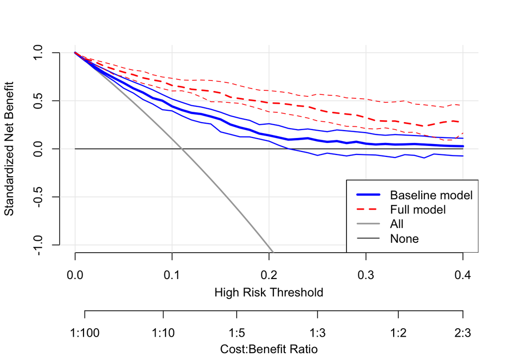

```r
#simulated case-control data with same variables as above
data(dcaData_cc)

#estimated from the population where the
#case-control sample comes from.
population.rho = 0.11

baseline.model_cc <- decision_curve(Cancer~Age + Female + Smokes,
                                    data = dcaData_cc,
                                    thresholds = seq(0, .4, by = .01),
                                    bootstraps = 25,
                                    study.design = "case-control",
                                    population.prevalence = population.rho)

full.model_cc <- decision_curve(Cancer~Age + Female + Smokes + Marker1 + Marker2,
                                data = dcaData_cc,
                                thresholds = seq(0, .4, by = .01),
                                bootstraps = 25,
                                study.design = "case-control",
                                population.prevalence = population.rho)


plot_decision_curve( list(baseline.model_cc, full.model_cc),
                   curve.names = c("Baseline model", "Full model"),
                   col = c("blue", "red"),
                   lty = c(1,2),
                   lwd = c(3,2, 2, 1),
                   legend.position = "bottomright")
```

## Cross-validation

We provide a wrapper to perform k-fold cross-validation to obtain bias corrected decision curves. Once `cv_decision_curve` is called, all plot and summary functions work the same as shown above for `decision_curve` output. Confidence interval calculation is not available at this time for cross-validated curves.

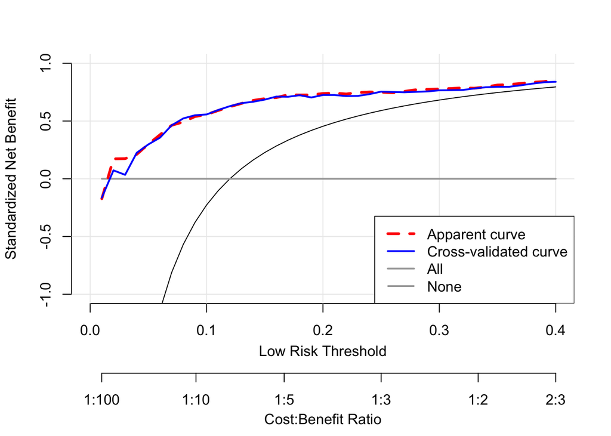

```r
full.model_cv <- cv_decision_curve(Cancer~Age + Female + Smokes + Marker1 + Marker2,
                                    data = dcaData,
                                    folds = 5,
                                    thresholds = seq(0, .4, by = .01),
                                   policy = "opt-out")

full.model_apparent <- decision_curve(Cancer~Age + Female + Smokes + Marker1 + Marker2,
                                data = dcaData,
                                thresholds = seq(0, .4, by = .01),
                                confidence.intervals = 'none', policy = "opt-out")


plot_decision_curve( list(full.model_apparent, full.model_cv),
                   curve.names = c("Apparent curve", "Cross-validated curve"),
                   col = c("red", "blue"),
                   lty = c(2,1),
                   lwd = c(3,2, 2, 1),
                   legend.position = "bottomright")
```

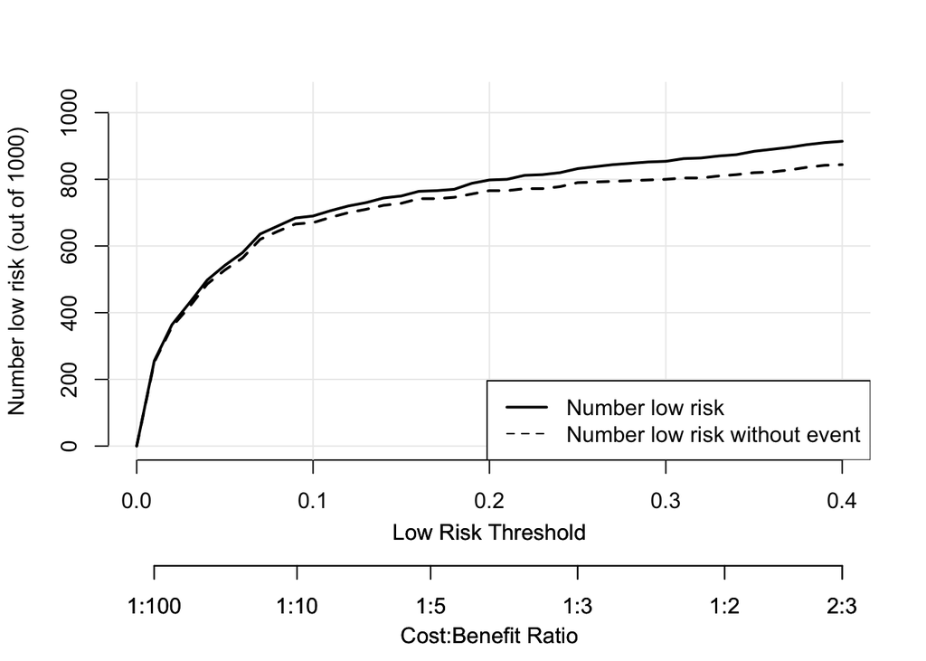

```r
plot_clinical_impact(full.model_cv, legend.position = "bottomright")
```

## References

Vickers AJ, Elkin EB. *Decision curve analysis: a novel method for evaluating prediction models.* Medical Decision Making. 2006 Nov-Dec;26(6):565-74.

Kerr KF, Brown MD, Zhu K, Janes H. *Assessing the Clinical Impact of Risk Prediction Models With Decision Curves: Guidance for Correct Interpretation and Appropriate Use.* J Clin Oncol. 2016; 34(21):2534-40.